# Q2 - Shared and distinct transcriptional signatures

PsychAD - Cross-disease comparison of schizophrenia and bipolar disorder

Author

Mariam H.

```r
suppressPackageStartupMessages({
  library(ggplot2)
  library(knitr)
  library(here)})

source(here::here("02_CODE", "scripts", "utils_figures.R"))

col_q2 <- unname(project_colours$Q2["dark"])
col_groups <- c(Control = "grey60", col_disease[c("SCZ", "BD")])

theme_set(theme_project(base_size = 11) + theme(plot.title = element_text(hjust = 0.5)))

fig_dir <- here::here("04_FIGURES", "Q2_differential_expression")
dir.create(fig_dir, recursive = TRUE, showWarnings = FALSE)
```

# 1 Overview

## 1.1 Research objectives

**Research question :** Do schizophrenia (SCZ) and bipolar disorder (BD) share cell-type-specific transcriptional alterations in the human prefrontal cortex ?

**Relationship with Q2_1 :** The first Q2 notebook identifies disease-associated differential expression separately within each cell subclass, the present analysis compares these results across diagnoses to determine where transcriptional effects converge, diverge or differ significantly between SCZ and BD.

Three contrasts were analyzed across 23 eligible cell subclasses :

- SCZ versus Control,
- BD versus Control,
- SCZ versus BD.

This notebook is using this results in order to investigate shared and distinct transcriptional signatures accross psychiatric diagnoses.

No additional differential expression models are fitted. Existing gene-level estimates are compared within each cell subclass.

**ImportantInterpretation framework**

A gene significant in SCZ versus Controls but not in BD versus Controls is not necessarily specific to schizophrenia.

Statistical significant depends on effect size, variability and sample size. Disease-associated signatures are first described according to their significance patterns, while the direct contrast between SCZ and BD is examined separately to assess evidence for diagnostic-related differences.

# 2 Input validation

## 2.1 Load DESeq2 summary

The analysis uses the complete subclass-specific DESeq2 results generated in the first Q2 notebook.

Original gene-level statistics and adjusted p-values are preserved. No additional filtering or multiple-testing correction is performed before the cross-disease comparisons.

```r
#Primary Q2 results
q2_dir <- here::here("03_RESULTS", "Q2_differential_expression")
deg_dir <- file.path(q2_dir, "DEG")

#Consolidated export for Q3 (different directory)
q3_dir <- here::here("01_DATA", "processed")

#Cross-disease comparison outputs
comparison_dir <- file.path(q2_dir, "cross_disease")
dir.create(comparison_dir, recursive = TRUE, showWarnings = FALSE)

#Load summary produced by Q2 notebook 01
summary_file <- file.path(q2_dir, "Q2_DESeq2_summary.csv")

stopifnot(file.exists(summary_file), dir.exists(deg_dir))

q2_summary <- read.csv(summary_file)

cat("Summary loaded:", nrow(q2_summary), "comparisons\n")
```

```
Summary loaded: 69 comparisons
```

```r
cat("Subclasses:", length(unique(q2_summary$Subclass)), "\n")
```

```
Subclasses: 23
```

```r
required_contrasts <- c("SCZ_vs_Control", "BD_vs_Control", "SCZ_vs_BD")
eligible_subclasses <- sort(unique(q2_summary$Subclass))
expected <-  expand.grid(Subclass = eligible_subclasses, Contrast = required_contrasts, stringsAsFactors = FALSE)

summary_keys <- paste(q2_summary$Subclass, q2_summary$Contrast, sep = "__")
expected_keys <-paste(expected$Subclass, expected$Contrast, sep = "__")

stopifnot(nrow(q2_summary) == 69, length(eligible_subclasses) == 23, !anyDuplicated(summary_keys), setequal(summary_keys, expected_keys))

knitr::kable(data.frame(Characteristic = c("Eligible subclasses", "Diagnostic contrasts", "Subclass-level comparisons"), Value = c(length(eligible_subclasses), length(required_contrasts), nrow(q2_summary))), caption = "Input summary for cross-disease comparison")
```

Input summary for cross-disease comparison

| Characteristic | Value |
| --- | --- |
| Eligible subclasses | 23 |
| Diagnostic contrasts | 3 |
| Subclass-level comparisons | 69 |

## 2.2 Verify gene-level files

Before loading the results, each expected CSV file is checked for existence, non-zero file size and a readable header.

```r
expected_files <- file.path(deg_dir, paste0(expected$Subclass, "_", expected$Contrast, ".csv"))

required_columns <- c("gene", "log2FoldChange", "padj")

check_file <- function(f) {
  if (!file.exists(f)) {return("Missing")}

  size <- file.info(f)$size

  if (is.na(size) || size == 0) {return("Empty")}

  tryCatch({
    x <- read.csv(f, nrows = 1, check.names = FALSE)
    #Identify missing columns
    missing_cols <- setdiff(required_columns, names(x))
    if (length(missing_cols) > 0) {
      return(paste("Missing columns:", paste(missing_cols, collapse = ", ")))}
    #Ensure at least one data row exists
    if (nrow(x) == 0L) {return("No data rows")}
    NA_character_
  }, error = function(e) {paste("Unreadable:", conditionMessage(e))})}

issues <- vapply(expected_files, check_file, character(1), USE.NAMES = FALSE)

bad_files <- data.frame(File = expected_files, Issue = issues)
bad_files <- bad_files[!is.na(bad_files$Issue), , drop = FALSE]

if (nrow(bad_files) > 0) {print(bad_files)
  stop("Some DESeq2 result files failed validation.")}

cat("Validation successful:", length(expected_files), "DESeq2 files available.\n")
```

```
Validation successful: 69 DESeq2 files available.
```

**NoteExpected results**

The input should contain **23 cell subclasses**, **3 diagnostic contrasts** and **69 readable gene-level CSV files**.

This validation step let us check if there are any incomplete outputs left from the execution of previous Q2 notebook.

# 3 Shared transcriptional signatures

Now, the first true biological analysis can be performed : identifying, for each subclass, the genes whose expression changes are significant in both disorders.

Five categories were distinguished :

- **Shared concordant** : Significant in SCZ and BD, with log2FC values of the same sign
- **Shared opposite** : Significant in both, with log2FC values of opposite signs
- **SCZ significant only** : Significant in SCZ but not in BD
- **BD significant only** : Significant in BD but not in SCZ
- **Neither significant** : Not significant in either comparison

Genes for which a comparison is not possible (due to a missing padj) are placed in a sixth category, ‘Not comparable’. This prevents them from being incorrectly regarded as insignificant.

## 3.1 Gene-level comparison strategy

**NoteStrategy**

For each cell subclass, gene-level results from the SCZ versus Control and BD versus Control contrasts are matched using gene identifiers.

Genes are classified based on their adjusted p-values (FDR < 0.05) and direction of their log2 fold change.

The direct comparison between SCZ and BD is retained to support further investigations of diagnostic differences.

## 3.2 Compute shared and diagnosis-associated signatures

```r
read_contrast <- function(sc, contrast, suffix){
  f <- file.path(deg_dir, paste0(sc, "_", contrast, ".csv"))
  x <- read.csv(f, check.names = FALSE)
  stopifnot(!anyDuplicated(x$gene), all(c("gene", "log2FoldChange", "padj") %in% names(x)))
  out <- x[ , c("gene", "log2FoldChange", "padj")]
  names(out) <- c("gene", paste0("lfc_", suffix), paste0("padj_", suffix))
  out}

signature_summaries <-list()

for (sc in eligible_subclasses) {
  scz <- read_contrast(sc, "SCZ_vs_Control", "SCZ")
  bd <- read_contrast(sc, "BD_vs_Control", "BD")
  direct <- read_contrast(sc, "SCZ_vs_BD", "Direct")
  dat <- Reduce(
    function(x, y) merge(x, y, by = "gene", sort = FALSE),
    list(scz, bd, direct))
  #All contrasts share the same genes
  stopifnot(nrow(dat) == nrow(scz),
            nrow(dat) == nrow(bd),
            nrow(dat) == nrow(direct))
  #Comparable genes
  comparable <- (is.finite(dat$lfc_SCZ) &
                   is.finite(dat$lfc_BD) &
                   is.finite(dat$padj_SCZ) &
                   is.finite(dat$padj_BD))
  sig_scz <- comparable & dat$padj_SCZ < 0.05
  sig_bd <- comparable & dat$padj_BD < 0.05
  both_sig <- sig_scz & sig_bd

  same_direction <- (sign(dat$lfc_SCZ) == sign(dat$lfc_BD))

  #Assign mutually exclusive categories
  dat$signature_class <- "Not comparable"
  dat$signature_class[comparable] <- "Neither significant"
  dat$signature_class[sig_scz & !sig_bd] <- "SCZ significant only"
  dat$signature_class[sig_bd & !sig_scz] <- "BD significant only"
  dat$signature_class[both_sig & same_direction] <- "Shared concordant"
  dat$signature_class[both_sig & !same_direction] <- "Shared opposite"

  #Correlation among genes with finite effects
  finite_lfc <- is.finite(dat$lfc_SCZ) & is.finite(dat$lfc_BD)

  lfc_cor <-  if (sum(finite_lfc) >= 3){
    suppressWarnings(cor(
      dat$lfc_SCZ[finite_lfc],
      dat$lfc_BD[finite_lfc],
      method = "spearman"))
  } else {NA_real_}

  #Subclass-level summary
  signature_summaries[[sc]] <- data.frame(
    Subclass = sc,
    Genes_total = nrow(dat),
    Genes_comparable = sum(comparable),
    Shared_concordant = sum(dat$signature_class == "Shared concordant"),
    Shared_opposite = sum(dat$signature_class == "Shared opposite"),
    SCZ_only = sum(dat$signature_class == "SCZ significant only"),
    BD_only = sum(dat$signature_class == "BD significant only"),
    Neither = sum(dat$signature_class == "Neither significant"),
    Not_comparable = sum(dat$signature_class == "Not comparable"),
    Spearman_LFC = lfc_cor,
    Direct_SCZ_BD_DEG = sum(dat$padj_Direct < 0.05, na.rm = TRUE))

  #Save gene-level comparison to do downstream plots
  saveRDS(dat, file.path(comparison_dir, paste0(sc, "_comparison.rds")))
  rm(scz, bd, direct, dat)
  invisible(gc(verbose = FALSE))}

signature_summary <-do.call(rbind, signature_summaries)
rownames(signature_summary) <- NULL

stopifnot(nrow(signature_summary) == 23L)

write.csv(signature_summary, file.path(comparison_dir, "Q2_shared_signature_summary.csv"), row.names = FALSE)
```

## 3.3 Summary of shared signatures

```r
top_shared <- head(signature_summary[
  order(signature_summary$Shared_concordant, decreasing = TRUE),
  c("Subclass", "Shared_concordant", "Shared_opposite", "SCZ_only", "BD_only", "Direct_SCZ_BD_DEG", "Spearman_LFC")], 10)

knitr::kable(top_shared, digits = 3, caption = "Top 10 cell subclasses ranked by the number of concordant shared DEGs")
```

Top 10 cell subclasses ranked by the number of concordant shared DEGs

|  | Subclass | Shared_concordant | Shared_opposite | SCZ_only | BD_only | Direct_SCZ_BD_DEG | Spearman_LFC |
| --- | --- | --- | --- | --- | --- | --- | --- |
| 2 | EN_L2_3_IT | 192 | 2 | 2261 | 462 | 164 | 0.262 |
| 1 | Astro | 183 | 1 | 279 | 908 | 5 | 0.245 |
| 22 | PC | 144 | 0 | 181 | 367 | 3 | 0.407 |
| 5 | EN_L3_5_IT_3 | 124 | 0 | 840 | 190 | 2 | 0.334 |
| 19 | Micro | 74 | 0 | 209 | 419 | 47 | 0.535 |
| 4 | EN_L3_5_IT_2 | 68 | 0 | 631 | 196 | 12 | 0.289 |
| 11 | Endo | 37 | 2 | 810 | 79 | 108 | 0.259 |
| 18 | IN_VIP | 35 | 0 | 698 | 119 | 5 | 0.265 |
| 17 | IN_SST | 34 | 0 | 802 | 67 | 4 | 0.306 |
| 15 | IN_PVALB | 27 | 0 | 230 | 174 | 15 | 0.298 |

```r
cat("Subclasses analyzed : ", nrow(signature_summary))
```

```
Subclasses analyzed :  23
```

**NoteHow to interpret these categories**

The cross-disease comparison identified overlapping transcriptional signatures between schizophrenia (SCZ) and bipolar disorder (BD), with marked differences across cell subclasses.

The highest number of concordant shared differentially expressed genes was observed in **EN_L2_3_IT excitatory neurons (192 genes)**, followed by **astrocytes (183 genes)**, **pericytes (144 genes)** and **EN_L3_5_IT_3 excitatory neurons (124 genes)**.

In contrast, **shared significant genes with opposite directions of regulation were uncommon among the leading subclasses**, with only 2 identified for EN_L2_3_IT, one in astrocyte and two in endothelial cells.

The distribution of diagnosis-associated significance patterns also differed across populations. EN_L2_3_IT neurons showed 2 261 significant genes only in SCZ comparison, whereas astrocytes showed 908 significant genes only in BD comparison.

**These findings suggest that schizophrenia and bipolar disorder exhibit both shared and distinct patterns of detectable transcriptional alterations.**

Genes significant in only one disease versus control can not automitacally be considered disease specific. Moreover, genes lacking an adjusted p-value in either contrast were excluded from the analysis. **Direct SCZ-BD comparisons and effect-size concordance analyses are required** before drawing any conclusion regarding diagnostic specificity.

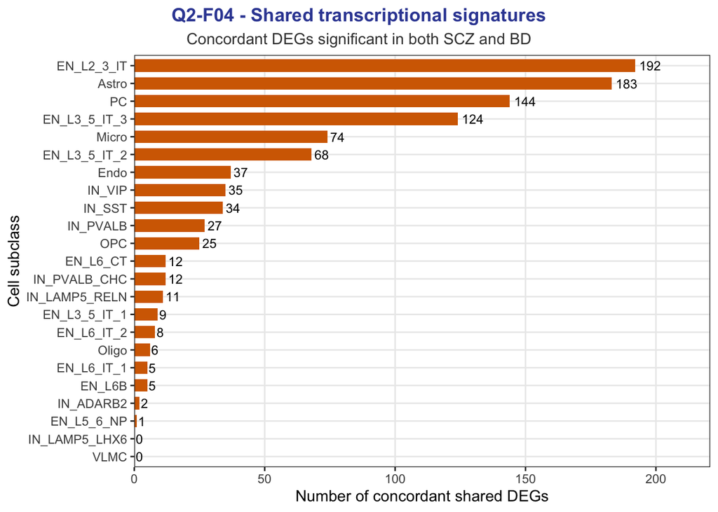

```r
plot_shared <- signature_summary[order(signature_summary$Shared_concordant, decreasing = TRUE), , drop = FALSE]

#Order subclasses by shared DEG count
plot_shared$Subclass <- factor(plot_shared$Subclass, levels = rev(plot_shared$Subclass))

p_shared <- ggplot(plot_shared,aes(x = Subclass, y = Shared_concordant)) +
  geom_col(fill = unname(project_colours$Q2["dark"]),width = 0.7) +
  geom_text(aes(label = Shared_concordant), hjust = -0.2, size = 3.2) +
  coord_flip() +
  scale_y_continuous(expand = expansion(mult = c(0, 0.15))) +
  labs(title = "Q2-F04 - Shared transcriptional signatures",
    subtitle = "Concordant DEGs significant in both SCZ and BD",
    x = "Cell subclass",
    y = "Number of concordant shared DEGs") +
  theme_project(base_size = 11) +
  theme(plot.title = element_text(hjust = 0.5), plot.subtitle = element_text(hjust = 0.5))

save_figure(p = p_shared, name = "Q2_F04_Shared_DEGs_by_subclass", dir = fig_dir, width = 10, height = 8)

p_shared
```

**NoteHow to read Figure Q2-F04**

Each bar represents the number of genes significantly differentially expressed in both SCZ and BD versus controls (FDR < 0.05), with changes in the same direction.

Cell subclasses are ranked by the number of concordant shared DEGs, from highest to lowest. Longer bars indicate greater overlap between the two disorders.

**TipInterpretation**

Shared concordant DEGs were detected across multiple neuroncal and non-neuronal cell-subclasses. This indicates partial overlapping transcriptional alterations between SCZ and BD.

The highest number of concordant shared DEGs was observed in **EN_L2_3_IT excitatory neurons (192 genes)**, followed by **astrocytes (183 genes)**, **pericytes (144 genes)** and **EN_L3_5_IT_3 excitatory neurons (124 genes)**.

Other neuronal and glial subclasses exhibited smaller shared signatures, including microglia, EN_L3_5_IT_2 neurons and endothelial cells. No concordant genes were found in VLMC and IN_LAMP5_LHX6.

This suggets that shared disease-associated transcriptional signatures are distributed all accross cell subclasses, rather than being restricted to a distinct neuronal or glial population.

However, the number of shared DEGs depends on statitiscal power, gene expression and number of detectable genes. Consequently, larger DEG overlaps should not simply be interepreted as stronger biological similarity between disorders. Complementary comparison of gene-level effect sizes if therefore needed.

```r
knitr::kable(signature_summary[order(signature_summary$Spearman_LFC, decreasing = TRUE),
    c("Subclass", "Spearman_LFC", "Shared_concordant", "Shared_opposite", "Direct_SCZ_BD_DEG")], digits = 3, caption = "Cross-disease effect-size concordance across cell subclasses.")
```

Cross-disease effect-size concordance across cell subclasses.

|  | Subclass | Spearman_LFC | Shared_concordant | Shared_opposite | Direct_SCZ_BD_DEG |
| --- | --- | --- | --- | --- | --- |
| 19 | Micro | 0.535 | 74 | 0 | 47 |
| 10 | EN_L6B | 0.463 | 5 | 0 | 0 |
| 22 | PC | 0.407 | 144 | 0 | 3 |
| 9 | EN_L6_IT_2 | 0.380 | 8 | 0 | 1 |
| 8 | EN_L6_IT_1 | 0.380 | 5 | 0 | 7 |
| 7 | EN_L6_CT | 0.351 | 12 | 0 | 1 |
| 5 | EN_L3_5_IT_3 | 0.334 | 124 | 0 | 2 |
| 17 | IN_SST | 0.306 | 34 | 0 | 4 |
| 15 | IN_PVALB | 0.298 | 27 | 0 | 15 |
| 4 | EN_L3_5_IT_2 | 0.289 | 68 | 0 | 12 |
| 18 | IN_VIP | 0.265 | 35 | 0 | 5 |
| 21 | OPC | 0.264 | 25 | 0 | 15 |
| 2 | EN_L2_3_IT | 0.262 | 192 | 2 | 164 |
| 12 | IN_ADARB2 | 0.261 | 2 | 0 | 0 |
| 11 | Endo | 0.259 | 37 | 2 | 108 |
| 1 | Astro | 0.245 | 183 | 1 | 5 |
| 6 | EN_L5_6_NP | 0.236 | 1 | 0 | 0 |
| 14 | IN_LAMP5_RELN | 0.211 | 11 | 0 | 17 |
| 20 | Oligo | 0.199 | 6 | 0 | 25 |
| 23 | VLMC | 0.197 | 0 | 0 | 14 |
| 16 | IN_PVALB_CHC | 0.195 | 12 | 0 | 1 |
| 3 | EN_L3_5_IT_1 | 0.193 | 9 | 0 | 18 |
| 13 | IN_LAMP5_LHX6 | 0.192 | 0 | 0 | 0 |

**TipInterpretation**

Gene-level effect size comparisons showed positive but heteregeneous correlation between SCZ and BD associated transcriptional changes across all 23 eligible cell subclasses.

Spearman correlations ranged from 0.192 to 0.535, showing weak to moderate concordance in estimated log2 fold changes.

**The strongest correlation was observed in microglia (0.535)**, followed by EN_L6B excitatory neurons (0.463) and pericytes (0.407).

Interestingly, the subclasses with the largest numbers of concordant shared DEGs did not exhibit the strongest genome-wide effect size correlations (EN_L2_3_IT neurons and astrocytes results).

This highlights an relevant distinction between significant gene overlap and trancriptome wide effect size concordance. DEG overlap focuses on genes meeting statistical significance thresholds in both disorders, while Spearman correlations summarize the relative consistency of estimated effects accross a much larger set of genes.

Direct SCZ-BD contrast identified differences in selected subclasses : EN_L2_3_IT (164 DEGs), endothelial cells (108 DEGs) and microglia (47 DEGs).

All this results indicate that SCZ and BD exhibit partially shared transcriptional signatures, with varying degrees of concordance and diagnostic differentiation across the cell subclasses.

Still, these correlations remain descriptive. Observed correlations should not be interpreted as definitive evidence of shared causal mechanisms.

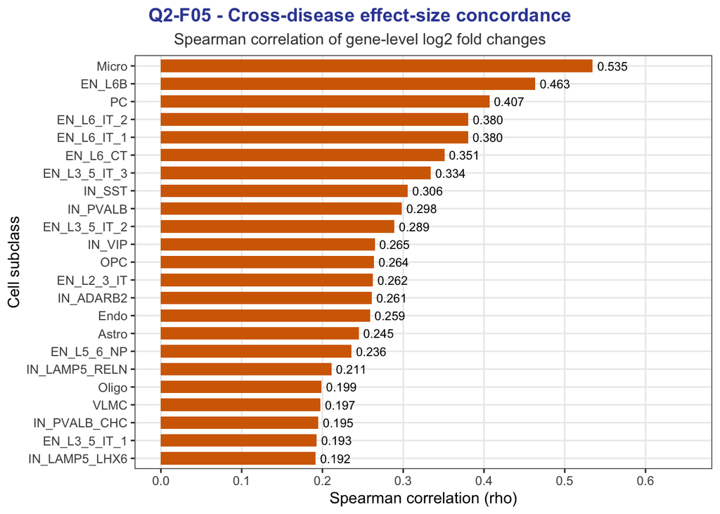

```r
corr_plot <- signature_summary[order(signature_summary$Spearman_LFC, decreasing = TRUE), , drop = FALSE]
corr_plot$Subclass <- factor(corr_plot$Subclass, levels = rev(corr_plot$Subclass))

#Figure Q2-F05
p_corr <- ggplot(corr_plot, aes(x = Subclass, y = Spearman_LFC)) +
  geom_col(fill = unname(project_colours$Q2["dark"]), width = 0.7) +
  geom_text(aes(label = sprintf("%.3f", Spearman_LFC)), hjust = -0.15, size = 3) +
  coord_flip() +
  scale_y_continuous(limits = c(0, 0.65), breaks = seq(0, 0.6, by = 0.1)) +
  labs(
    title = "Q2-F05 - Cross-disease effect-size concordance",
    subtitle = "Spearman correlation of gene-level log2 fold changes",
    x = "Cell subclass",
    y = "Spearman correlation (rho)") +
  theme_project(base_size = 11) +
  theme(plot.title = element_text(hjust = 0.5), plot.subtitle = element_text(hjust = 0.5))

save_figure(p = p_corr, name = "Q2_F05_Effect_size_concordance", dir = fig_dir, width = 10, height = 8)

p_corr
```

**NoteHow to read Figure Q2-F05**

Each bar represents the Spearman correlation between gene-level log2 fold changes estimated for SCZ versus Control and BD versus Control within one cell subclass.

Correlations were calculated using genes with finite effect estimates in both contrasts, independently of their statistical significance.

Higher positive correlations indicate greater consistency in the ranking of gene-level transcriptional effects between the two disorders.

**TipInterpretation**

Cross-disease effect size correlations were **positive across all 23 eligible cell subclasses ranging from 0.192 to 0.535**.

Strongest concordance was observed in **microglia** followed by EN_L6B excitatory neurons and pericytes.

In contrast, EN_L2_3_IT neurons and astrocytes exhibited modest correlations despite having the highest numbers of concordant shared DEGs.

These findings demonstrate that **the number of shared significant genes does not reflect the overall degree of transcriptional effect size concordance**.

The results suggest heterogeneous molecular similarities between SCZ and BD across cell subclasses, with microglia showing the strongest relative concordance among analyzed populations.

# 4 Gene-level comparison of disease effects

## 4.1 SCZ versus BD effect-size scatterplots

Complementary to subclass-level correlation analysis, gene-level log2 fold changes are compared in three populations : microglia, EN_L2_3_IT excitatory neurons and astrocytes.

These populations were selected to illustrete distinct combinations of significant-gene overlap and transcriptome effect size concordance.

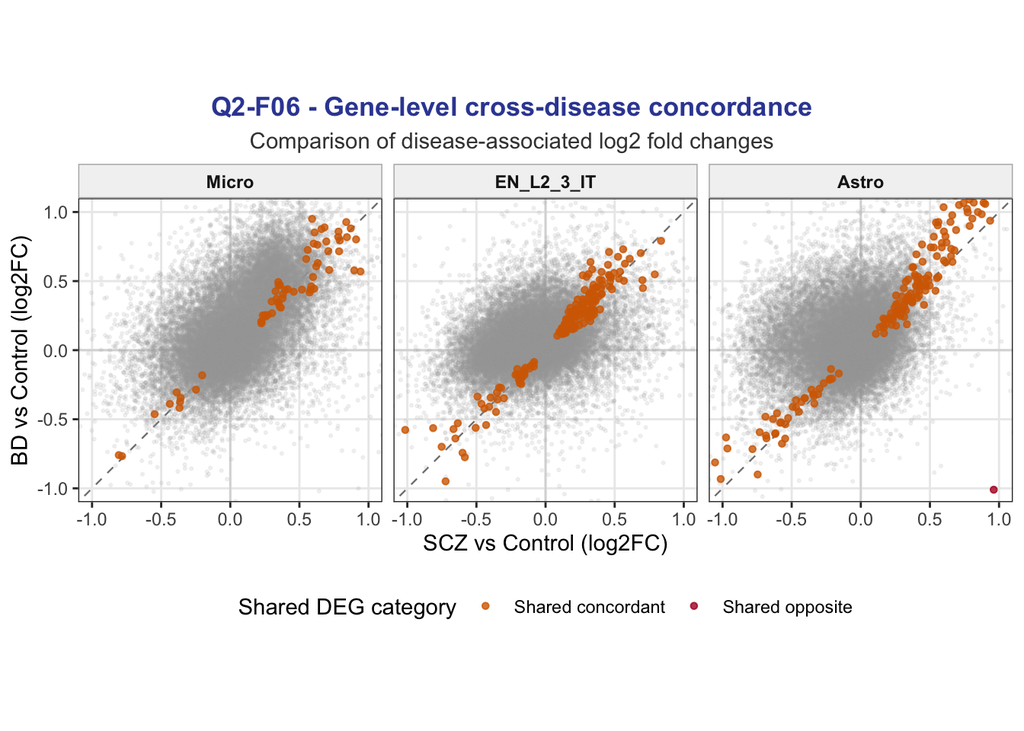

```r
selected_subclasses <- c("Micro", "EN_L2_3_IT", "Astro")

scatter_list <- lapply(selected_subclasses, function(sc) {
  dat <- readRDS(file.path(comparison_dir, paste0(sc, "_comparison.rds")))
  keep <- is.finite(dat$lfc_SCZ) & is.finite(dat$lfc_BD)
  data.frame(Subclass = sc, lfc_SCZ = dat$lfc_SCZ[keep], lfc_BD = dat$lfc_BD[keep], signature_class = dat$signature_class[keep])})

scatter_data <- do.call(rbind, scatter_list)
scatter_data$Subclass <- factor(scatter_data$Subclass, levels = selected_subclasses)

scatter_data$shared <- scatter_data$signature_class %in% c("Shared concordant", "Shared opposite")

axis_limit <- quantile(abs(c(scatter_data$lfc_SCZ, scatter_data$lfc_BD)), probs = 0.995, na.rm = TRUE)
axis_limit <- max(1, min(6, ceiling(axis_limit)))

#Figure Q2-F06
p_scatter <- ggplot() +
  geom_abline(slope = 1, intercept = 0, linetype = "dashed", colour = "grey50", linewidth = 0.4) +
  geom_hline(yintercept = 0, colour = "grey85") +
  geom_vline(xintercept = 0, colour = "grey85") +
  geom_point(data = scatter_data[!scatter_data$shared, ], aes(x = lfc_SCZ, y = lfc_BD), colour = "grey65", alpha = 0.12, size = 0.45) +
  geom_point(data = scatter_data[scatter_data$shared, ], aes(x = lfc_SCZ, y = lfc_BD, colour = signature_class), size = 1.2, alpha = 0.8) +
  scale_colour_manual(
    values = c("Shared concordant" = unname(project_colours$Q2["dark"]), "Shared opposite" = unname(col_disease["BD"])), name = "Shared DEG category") +
  facet_wrap(~ Subclass, nrow = 1) +
  coord_fixed(xlim = c(-axis_limit, axis_limit), ylim = c(-axis_limit, axis_limit), ratio = 1) +
  labs(title = "Q2-F06 - Gene-level cross-disease concordance",
    subtitle = "Comparison of disease-associated log2 fold changes",
    x = "SCZ vs Control (log2FC)",
    y = "BD vs Control (log2FC)") +
  theme_project(base_size = 11) +
  theme(plot.title = element_text(hjust = 0.5), plot.subtitle = element_text(hjust = 0.5), strip.text = element_text(face = "bold"))

save_figure(p = p_scatter, name = "Q2_F06_Cross_disease_scatterplots", dir = fig_dir, width = 13, height = 5.5)

p_scatter
```

**NoteHow to read Figure Q2-F06**

Each point represents a gene with finite log2 fold-change estimates in both disease-versus-control contrasts.

The horizontal axis represents the estimated effect in SCZ versus Control, while the vertical axis represents the estimated effect in BD versus Control.

Grey points represent other genes; orange points highlight significant shared genes with concordant directions, and red points highlight significant shared genes with opposite directions.

The dashed diagonal indicates equal estimated effects in both disorders. Points in the upper-right and lower-left quadrants have concordant directions, whereas points in the other two quadrants have opposite directions.

The axes are zoomed for readability. Genes outside the displayed range remain included in the previously calculated correlation statistics.

**TipInterpretation**

The three selected subclasses illustrate distinct relationships between significant-gene overlap and genome-wide transcriptional concordance.

**Microglia** exhibited the strongest correlation between SCZ and BD associated effect, despite having only 74 concordant shared DEGs.

In contrast, **EN_L2_3_IT neurons** and **astrocytes** showed considerable overlap in significant genes (192 and 183 matching common DEGs, respectively), but lower transcriptome-wide correlations (rho = 0.262 and 0.245, respectively).

This suggests that a large group of jointly significant genes can co-exist with moderate overlap across the transcriptome.

The highlighted genes represent candidates for shared transcriptional changes. Nevertheless, their shared significance in the two ‘disease versus control’ contrasts does not imply equivalent effect sizes or identical underlying biological mechanisms.

These results underscore the importance of supplementing DEG overlap analyses with direct comparisons between diagnostic groups.

# 5 Direct diagnostic differences

## 5.1 Significant genes in the SCZ versus BD contrast

To identify evidence of transcriptional differences between SCZ and BD, direct contrast is examined independently of the overlap-based categories.

```r
direct_results <- signature_summary[order(signature_summary$Direct_SCZ_BD_DEG, decreasing = TRUE),
  c("Subclass",
    "Shared_concordant",
    "SCZ_only",
    "BD_only",
    "Direct_SCZ_BD_DEG"),
  drop = FALSE]

knitr::kable(head(direct_results, 10), caption = "Top 10 cell subclasses by the number of significant genes in the direct SCZ versus BD contrast")
```

Top 10 cell subclasses by the number of significant genes in the direct SCZ versus BD contrast

|  | Subclass | Shared_concordant | SCZ_only | BD_only | Direct_SCZ_BD_DEG |
| --- | --- | --- | --- | --- | --- |
| 2 | EN_L2_3_IT | 192 | 2261 | 462 | 164 |
| 11 | Endo | 37 | 810 | 79 | 108 |
| 19 | Micro | 74 | 209 | 419 | 47 |
| 20 | Oligo | 6 | 131 | 143 | 25 |
| 3 | EN_L3_5_IT_1 | 9 | 529 | 30 | 18 |
| 14 | IN_LAMP5_RELN | 11 | 321 | 75 | 17 |
| 15 | IN_PVALB | 27 | 230 | 174 | 15 |
| 21 | OPC | 25 | 93 | 439 | 15 |
| 23 | VLMC | 0 | 56 | 0 | 14 |
| 4 | EN_L3_5_IT_2 | 68 | 631 | 196 | 12 |

```r
write.csv(direct_results, file.path(comparison_dir, "Q2_direct_SCZ_vs_BD_summary.csv"), row.names = FALSE)
```

**TipInterpretation**

The direct SCZ versus BD comparison revealed substantial differences in the number of significant genes across cell subclasses.

The strongest direct diagnostic differences were detected in **EN_L2_3_IT (164 DEGs)**, followed by **endothelial cells (108 DEGs)**, and **microglia (47 DEGs)**.

In comparison, astrocytes showed only 5 significant genes in the direct comparison, despite having 183 concordant shared DEGs in the disease versus control analysis.

These results shows the coexistence of shared transcriptional signatures and detectable differences between the two diseases. EN_L2_3_IT neurons and endothelilal cells emerge as important populations for investigating potential disease-associated distinctions.

Interpretation of these results remains limited by the unequal donor representation, ancestry imbalance and potentially unmeasured confounding factors.

# 6 Save cross-disease results and outputs

The cross-disease analysis reuses the gene-level DESeq2 results generated in the primary Q2 notebook. No additional differential expression models were fitted.

Subclass-specific comparison tables and summary statistics were saved separately from the original DESeq2 results.

# 7 Links with the other project questions

The cross-disease analysis provides a complementary interpretation of the transcriptomic alterations identified in Q2_1 and establishes several connections with the other questions of the PsychAD project.

| Project question | Contribution of Q2 | Perspective |
| --- | --- | --- |
| **Q1 - Cell-type composition** | Shared transcriptional signatures were identified in microglia, excitatory neurons and other cell subclasses. | Compare expression changes with alterations in cell population proportions. |
| **Q3 - Functional enrichment** | Complete DESeq2 statistics and shared or distinct gene signatures are available for SCZ and BD. | Investigate whether different genes converge on common biological processes and synaptic pathways. |
| **Q4 - Cell–cell communication** | Shared and diagnosis-associated transcriptional alterations were detected in neuronal, glial and vascular-associated subclasses. | Examine whether these populations participate in conserved or altered inferred signaling networks. |
| **Q5 - Transcriptomic ageing** | Disease-associated expression estimates were generated for each cell subclass, with age included as a covariate. | Investigate the relationship between disease-associated changes and ageing-related transcriptional programs. |

## 7.1 Overall contribution of Q2

Together, the two Q2 notebooks establish three complementary levels of evidence :

1. **Differential expression :** which genes show disease-associated changes within each cell subclass.
2. **Shared transcriptional signatures :** which significant changes are detected in both disorders and in which directions.
3. **Direct diagnostic differences :** which genes provide statistical evidence of differences between SCZ and BD.

These results provide a gene-level framework for interpreting the biological processes investigated in Q3, the inferred signaling networks examined in Q4, and the ageing-associated transcriptional patterns studied in Q5.

They support the investigation of **partially overlapping but heterogeneous molecular alterations** across psychiatric diagnoses, without assuming that shared expression changes necessarily imply shared mechanisms or that disease-associated signatures are causally related to the disorders.

# 8 Conclusion

**NoteConclusion**

This notebook investigated shared and distinct transcriptional alterations between SCZ and BD across 23 eligible cell subclassses of the human prefrontal cortex, using gene-level results from the primary donor-level pseudobulk DESeq2 analysis of the PsychAD HBCC cohort [1].

**Shared transcriptional signatures were identified across neuronal and non-neuronal populations.** The highest numbers of concordant shared DEGs were observed in EN_L2_3_IT, astrocytes, pericytes and EN_L3_5_IT_3 neurons. Shared significant genes with opposite direction were uncommon.

These observations are consistent with previous evidence of molecular convergence between SCZ and BD. Gandal et al. (2018) identified overlapping cortical gene-expression alterations in SCZ and BD (and other psychiatric disorders) [2]. Their findings also implicated neuronal and astroglial transcriptional activity, supporting the relevance of both neuronal and non-neuronal population in this analysis.

The involvement of excitatory neurons is consistent with what Ruzicka et al. (2024) reported : cell type specific transcriptional alterations in schizophrenia, particularly within excitatory neuronal populations of the prefrontal cortex [3].

This distinction indicates that significant gene overlap and transcriptome wide concordance capture different aspects of molecular similarity. Such heterogeneity is compatible with the founding of Lee et al. (2026), whose PsychAD atlas described shared and distinct transcriptional vulnerabilities across brain disorders.

**Direct SCZ versus BD comparisons revealed additional diagnostic differences**, particularly in EN_L2_3_IT neurons (164 DEGs), endothelilal cells (108 DEGs) and microglia. Astrocytes showed only 5 significant genes in the direct comparison, despite having 183 concordant shared DEGs.

These observations suggest that **shared and divergent transcriptional alterations can coexist within the same cell subclass**. This is consistent with what was found in the literature [2, 4].

Still, several limitations must be considered. SCZ and BD case control comparisons share the same control cohort, while differences in statistical power, donor representation and genetic ancestry may affet the estimated disease associations. Genes significant in only one disease versus control contrast can not directly be classified as disease-specific and absence of significance in direct comparison also does not equal to equivalence.

Overall, our results support **heterogeneous and partially overlapping cell subclass specific transcriptional signatures between SCZ and BD**, consistent with previous transcriptomic studies found in the literature.

The next step of this analysis is to investigate whether these candidate shared and divergent signatures converge on common biological processes though downstream functional enrichment analyses (Q3). Such analyses will be necessary before drawing conclusions about molecular pathways that may be involved in both disorders.

# 9 References

[1] Fullard, J. F., et al. (2025). Population-scale cross-disorder atlas of the human prefrontal cortex at single-cell resolution. Scientific Data, 12(1), 954. https://doi.org/10.1038/s41597-025-04687-5

[2] Gandal, M. J. et al. (2018). Shared molecular neuropathology across major psychiatric disorders parallels polygenic overlap. Science, 359(6376), 693‑697. https://doi.org/10.1126/science.aad6469

[3] Ruzicka, W. B., et al. (2024). Single-cell multi-cohort dissection of the schizophrenia transcriptome. Science, 384(6698), eadg5136. https://doi.org/10.1126/science.adg5136

[4] Lee, D., et al. (2026). Single-cell atlas of transcriptomic vulnerability across brain disorders. Nature, 657(8133), 988‑1002. https://doi.org/10.1038/s41586-025-09573-z